# Project 1 Text Mining

## Beginning

In this project, I would use Python to analyze the philosophy data base and to see if there are any interesting things, such as the relationship among different philosophy or schools. Let's start with import packages.

```python
# import packages
import numpy as np
import pandas as pd
import matplotlib.pyplot as plt

import nltk
# nltk.download('vader_lexicon')
from nltk.sentiment.vader import SentimentIntensityAnalyzer as sid
import text2emotion as te

from os import path
from PIL import Image
from wordcloud import WordCloud, STOPWORDS, ImageColorGenerator
```

```python
# read csv
df = pd.read_csv(r"C:\Users\94333\Python\Github\spring-2022-prj1-Hayinn\data\philosophy_data.csv")
df.dropna(inplace=True)
```

Now, use sentiment analysis to figure out the number of positive, negative, and neutral sentiment for different sentences written by different philosophers.

```python
# define a function to define the sentiment analysis result
def senan(c):
    if c>0:
        a = "pos"
    elif c<0:
        a = "neg"
    else:
        a ="neu"
    return a
```

```python
# use sentiment analysis processing data
Sid = sid()
df['scores'] = df['sentence_spacy'].apply(lambda sentence_spacy: Sid.polarity_scores(sentence_spacy))
df['compound'] = df['scores'].apply(lambda score_dict: score_dict['compound'])
df['comp_score'] = df['compound'].apply(senan)
df
```

|  | title | author | school | sentence_spacy | sentence_str | original_publication_date | corpus_edition_date | sentence_length | sentence_lowered | tokenized_txt | lemmatized_str | scores | compound | comp_score |
| --- | --- | --- | --- | --- | --- | --- | --- | --- | --- | --- | --- | --- | --- | --- |
| 0 | Plato - Complete Works | Plato | plato | What's new, Socrates, to make you leave your ... | What's new, Socrates, to make you leave your ... | -350 | 1997 | 125 | what's new, socrates, to make you leave your ... | ['what', 'new', 'socrates', 'to', 'make', 'you... | what be new , Socrates , to make -PRON- lea... | {'neg': 0.132, 'neu': 0.868, 'pos': 0.0, 'comp... | -0.2960 | neg |
| 1 | Plato - Complete Works | Plato | plato | Surely you are not prosecuting anyone before t... | Surely you are not prosecuting anyone before t... | -350 | 1997 | 69 | surely you are not prosecuting anyone before t... | ['surely', 'you', 'are', 'not', 'prosecuting',... | surely -PRON- be not prosecute anyone before ... | {'neg': 0.0, 'neu': 0.791, 'pos': 0.209, 'comp... | 0.4404 | pos |
| 2 | Plato - Complete Works | Plato | plato | The Athenians do not call this a prosecution b... | The Athenians do not call this a prosecution b... | -350 | 1997 | 74 | the athenians do not call this a prosecution b... | ['the', 'athenians', 'do', 'not', 'call', 'thi... | the Athenians do not call this a prosecution ... | {'neg': 0.192, 'neu': 0.808, 'pos': 0.0, 'comp... | -0.3346 | neg |
| 3 | Plato - Complete Works | Plato | plato | What is this you say? | What is this you say? | -350 | 1997 | 21 | what is this you say? | ['what', 'is', 'this', 'you', 'say'] | what be this -PRON- say ? | {'neg': 0.0, 'neu': 1.0, 'pos': 0.0, 'compound... | 0.0000 | neu |
| 4 | Plato - Complete Works | Plato | plato | Someone must have indicted you, for you are no... | Someone must have indicted you, for you are no... | -350 | 1997 | 101 | someone must have indicted you, for you are no... | ['someone', 'must', 'have', 'indicted', 'you',... | someone must have indict -PRON- , for -PRON- ... | {'neg': 0.0, 'neu': 1.0, 'pos': 0.0, 'compound... | 0.0000 | neu |
| ... | ... | ... | ... | ... | ... | ... | ... | ... | ... | ... | ... | ... | ... | ... |
| 360803 | Women, Race, And Class | Davis | feminism | But the socialization of housework including m... | But the socialization of housework including m... | 1981 | 1981 | 142 | but the socialization of housework including m... | ['but', 'the', 'socialization', 'of', 'housewo... | but the socialization of housework include me... | {'neg': 0.0, 'neu': 0.71, 'pos': 0.29, 'compou... | 0.8462 | pos |
| 360804 | Women, Race, And Class | Davis | feminism | The only significant steps toward endingdomest... | The only significant steps toward endingdomest... | 1981 | 1981 | 117 | the only significant steps toward endingdomest... | ['the', 'only', 'significant', 'steps', 'towar... | the only significant step toward endingdomest... | {'neg': 0.222, 'neu': 0.694, 'pos': 0.083, 'co... | -0.6124 | neg |
| 360805 | Women, Race, And Class | Davis | feminism | Working women, therefore, have a special and v... | Working women, therefore, have a special and v... | 1981 | 1981 | 90 | working women, therefore, have a special and v... | ['working', 'women', 'therefore', 'have', 'spe... | working woman , therefore , have a special an... | {'neg': 0.12, 'neu': 0.469, 'pos': 0.411, 'com... | 0.6808 | pos |
| 360806 | Women, Race, And Class | Davis | feminism | Moreover, under capitalism, campaigns for jobs... | Moreover, under capitalism, campaigns for jobs... | 1981 | 1981 | 199 | moreover, under capitalism, campaigns for jobs... | ['moreover', 'under', 'capitalism', 'campaigns... | moreover , under capitalism , campaign for jo... | {'neg': 0.0, 'neu': 0.894, 'pos': 0.106, 'comp... | 0.4939 | pos |
| 360807 | Women, Race, And Class | Davis | feminism | This strategy calls into question the validity... | This strategy calls into question the validity... | 1981 | 1981 | 126 | this strategy calls into question the validity... | ['this', 'strategy', 'calls', 'into', 'questio... | this strategy call into question the validity... | {'neg': 0.0, 'neu': 1.0, 'pos': 0.0, 'compound... | 0.0000 | neu |

360808 rows × 14 columns

## Among Authors

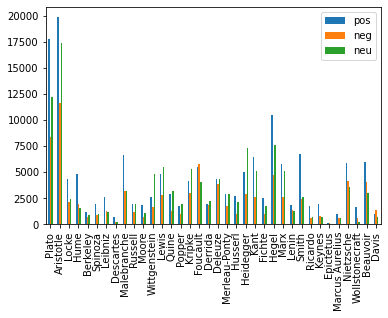

```python
# extract authors name
authors = pd.Series(df['author']).unique()

# plot a bar graph with authors and sentment analysis result
df2=pd.DataFrame(np.zeros((36, 3),int),index=pd.Series(df['author']).unique(),columns=pd.Index(['pos', 'neg',"neu"]))
for senti in ["pos", 'neg',"neu"]:
    for name in authors:
        tempdf = df[df['comp_score']==senti]
        tempdf = tempdf[tempdf["author"]==name]
        num = len(tempdf)
        df2[senti][name]=num

df2.plot.bar()
```

As shown in the bar graph, we can see most of them would have more positive sentiment sentenses, we can conclude that most philosophers are optimism in the fireld they were studying/thinking. However, I want to see further like: what schools would have different property compared to others, and how about the philosophers belong to that school?

## Among Schools

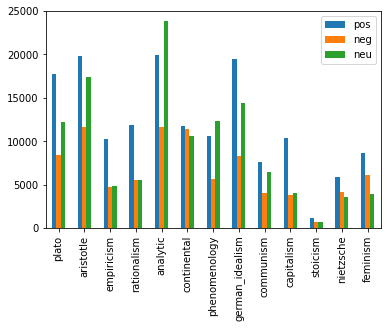

```python
# extract schools name
school = pd.Series(df['school']).unique()

# plot a bar graph with schools and sentment analysis result
df3=pd.DataFrame(np.zeros((13, 3),int),index=school,columns=pd.Index(['pos', 'neg',"neu"]))
for senti in ["pos", 'neg',"neu"]:
    for name in school:
        tempdf2 = df[df['comp_score']==senti]
        tempdf2 = tempdf2[tempdf2["school"]==name]
        num2 = len(tempdf2)
        df3[senti][name]=num2
df3.plot.bar()
```

We can easily group the schools by the relationship among pos, neg, and neu. Most schools would have the following property: **numbers of pos > numbers of neu > numbers of neg** .  
But I want to foucs on this school: **continental**. The reasonis that they have almost **the same amount of pos, neg, and neu sentiment sentences**. Let's dig deeper to see the author in this school.

```python
# to see authors belong to which schools
df.groupby("school")["author"].unique()
```

```
school
analytic           [Russell, Moore, Wittgenstein, Lewis, Quine, P...
aristotle                                                [Aristotle]
capitalism                                  [Smith, Ricardo, Keynes]
communism                                              [Marx, Lenin]
continental                             [Foucault, Derrida, Deleuze]
empiricism                                   [Locke, Hume, Berkeley]
feminism                           [Wollstonecraft, Beauvoir, Davis]
german_idealism                                [Kant, Fichte, Hegel]
nietzsche                                                [Nietzsche]
phenomenology                    [Merleau-Ponty, Husserl, Heidegger]
plato                                                        [Plato]
rationalism               [Spinoza, Leibniz, Descartes, Malebranche]
stoicism                                [Epictetus, Marcus Aurelius]
Name: author, dtype: object
```

```python
# to show the authors in continental group
df4 = df[df["school"] == 'continental']
cont = pd.Series(df4['author']).unique()
cont
```

```
array(['Foucault', 'Derrida', 'Deleuze'], dtype=object)
```

So we now know Foucault, Derrida, and Deleuze are in the continental school. Let's see their sentenses trends:

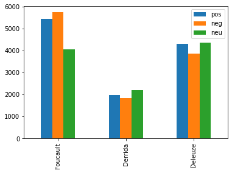

```python
# similar bar graph with only continental authors included
df5 = pd.DataFrame(np.zeros((3, 3),int),index=cont,columns=pd.Index(['pos', 'neg',"neu"]))
for senti in ["pos", 'neg',"neu"]:
    for name in cont:
        tempdf3 = df[df['comp_score']==senti]
        tempdf3 = tempdf3[tempdf3["author"]==name]
        num3 = len(tempdf3)
        df5[senti][name]=num3
df5.plot.bar()
```

Now we can see Foucault has a diffrent trend as other have, let see the word cloud for Foucault:

```python
# define wordcloud plot function
def plot_wordcloud(text,title):
    wordcloud = WordCloud(background_color="white",
                        stopwords = set(STOPWORDS),
                        max_words = 100,
                         max_font_size = 40,
                         relative_scaling = 1,
                         random_state = 3
    ).generate(str(text))
    fig = plt.figure(figsize = (8,8))
    plt.axis('off')
    plt.title(title)
    plt.imshow(wordcloud)
```

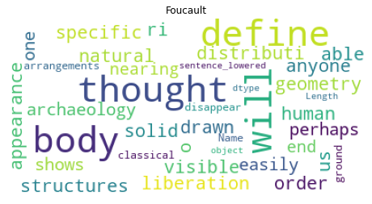

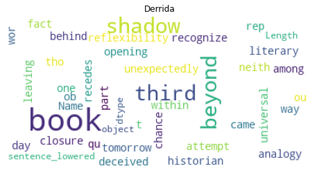

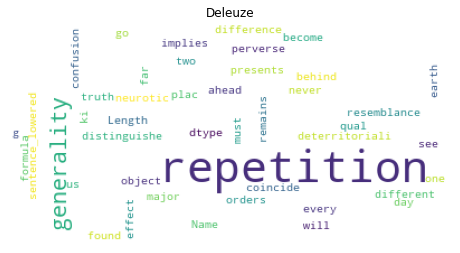

```python
# plot wordcloud for continental authors
for i in cont:
    could_0 = df.loc[df['author'] == i]['sentence_lowered']
    plot_wordcloud(could_0,i)
plt.show()
```

We can see that most of the words show in **wordcloud** are neutral, and some of them can be either positive or negative, regarding the context of the article. However, I notice that some words seems to be "mis-analysis", such as "ri", "o" in Foucault wordcloud. Then I found the sentence with "ri":

**"Mor ri's Grand dictionnaire historique of."**

I translated this sentence with Google translate and I get the following sentence in English:

**"Morri's Great Historical Dictionary of."**

Hence, we can see the previous sentence is written in French, then translated or quoted by the authors. So I search about Foucault, whose full name is Paul-Michel Foucault, a French philosopher, historian of ideas, writer, political activist, and literary critic. Then, a question raised in my mind: why would this book includes two languages? So, I search about the book and found the answer: This is the reference which quoted by the authors. Similar things happened on other two continental authors.

I want to see if this happens in other schools, so I pick another two schools, **nietzsche** and **feminism**, to see their word clouds. I assume I will find more **"positive"** words regarding they both have more positive sentment sentenses. Here are the results:

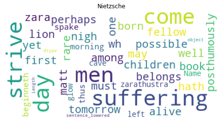

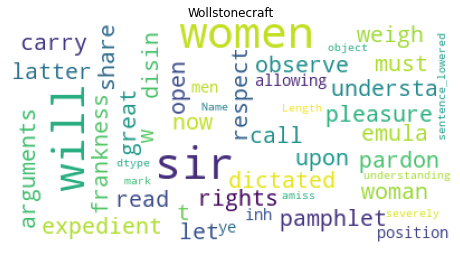

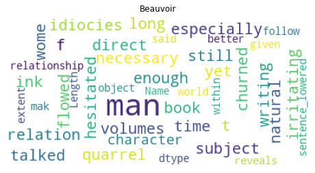

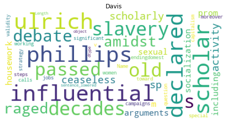

```python
# plot wordcloud for authors in nietzsche school and in feminism school
for i in ["nietzsche","feminism"]:
    df_3 =df.loc[df["school"]==i]
    author1 = pd.Series(df_3["author"]).unique()
    for j in author1:
        could_0 = df.loc[df['author'] == j]['sentence_lowered']
        plot_wordcloud(could_0,j)
```

We can still see some noise data listed in the wordcloud. For example, "t", "w", "ye", and"inh" listed in Wollstonecraft's wordcloud. So we can say that references generate data noise to analysis in our datasets. We can remove the references as a step to cleaning data next time to reduce the data noise.

Furthermore, I found something interesting with these four new wordclouds. If we just look at the wordclouds for these four authors, we might conclude that **Nietzsche** would be similar to **feminism**, because Nietzsche mentioned "men" and "children" often, just like Beauvoir mentioned "man" a lot.

Last but not least, though **Davis** is one of the feminism philosophers,but it seems like what she was sharing is diferent from other two authors, as she sldom mentioned sex, like "men" and "wemen", in her articles. We can deep further to see what's her points of view in the real world, compared to other two authors.

## Compare what we get to the real world

To analyze further, we meed to search up the real world situation, compared to what we get from sentiment analysis and wordcloud, to see if we get a correct understanding of the data.

We move little further and detailed, to see **if Nietzche school is similar to feminism school.** However, it is not. *Nietzsche's philosophy contemplates the meaning of values and their significance to human existence.* This means not only for women, Nietzsche's insight is for all human beings. This is no surprised why there are also so much "children" is listed in Nietzsche's wordcloud. Also, he mentioned the most about **"suffering"**, and we can tell he might talk much about how to make people suffer less and what they were suffering.

Last but not least, we can also tell the difference between Davis and other feminism authors. Unlike *Simone de Beauvoir* and *Mary Wollstonecraft*, *Angela Davis* actived in a stage **African-American Civil Rights Movement**. In this context, it is no wonder her words tend to be more aggressive, such as "raged" and "slavery".

## Conclusion

In conclusion, utilizing sentiment analysis, we can actually see the authors attitude and we can also guess about the era they were living. Also, we can tell what was going on based on the words authors used differently in diferent schools. Most importantly, we can use wordcloud to see the goal of the authors, and finally understand their school's goal.